# DATA2002 Individual Assignment

Author

530156989

Published

September 24, 2024

## 1 Introduction

The data in this report was sampled from a survey responded by DATA2X02 students. The question types were diverse, some of which include yes/no, open-ended and etc. Such question design enables the report to capitalize on both categorical and numerical responses to perform different hypothesis tests specific to each data type.

However, the randomness of this sample has to be interrogated. The selection of the respondents is not random and is likely affected by non-response bias and designed bias.

Non-response bias is inherent to this survey as students are not obliged to respond, so only the motivated students will likely answer the survey as they frequent the Canvas Page. This bias may surface in variables like WAM score and number of hours on studying per week.

Designed bias is spotted in questions like “place a consistency rating on sleep schedule”, which is ambiguous as respondents are left to make a judgement on what rating fits their perception of consistency. Furthermore, the wording may also cause confusion as some can interpret consistency as “consistent duration of sleep” or “consistently go to bed at a given hour”. An improvement is to change such question to yes/no format and define the key word in the question. Other questions like “how much time spent on short video apps” could be improved via specifying numerical units, otherwise the true values can be subjected to misinterpretation in the process of data wrangling.

The analysis of this report aims to gain some insights about the state of affair for international students in DATA2X02. The motivation lies against the backdrop of increasing media coverage that places international students’ role in the limelight of Australian tertiary education sector. Some of the primary concerns of international students are ease of finding jobs, their competitiveness for the job market and their ability to integrate into the Australian work force. This lends to the curiosity as to whether the reality is reflected in DATA2X02 student population.

Hence, some variables of interest in the data will consist of country of birth, work status, WAM and others.

## 2 Data Exploration and Cleaning

```r
#load the necessary libraries
library(tidyverse)
library(gendercoder)
library(janitor)
library(hms)
library(knitr)
theme_set(theme_bw())
x = readxl::read_excel("DATA2x02_survey_2024_Responses.xlsx")
```

FIrst, check the column names in the raw data set.

```r
colnames(x)
```

The column names are messy, so tidy them up by replacing them with short and concise names.

```r
old_names = colnames(x)
new_names = c(
  "timestamp",
  "target_grade",
  "assignment_preference",
  "trimester_or_semester",
  "age",
  "tendency_yes_or_no",
  "pay_rent",
  "urinal_choice",
  "stall_choice",
  "weetbix_count",
  "weekly_food_expenditure",
  "living_arrangements",
  "weekly_alcohol",
  "believe_in_aliens",
  "height",
  "commute",
  "daily_anxiety_frequency",
  "weekly_study_hours",
  "work_status",
  "social_media",
  "gender",
  "average_daily_sleep",
  "usual_bedtime",
  "sleep_schedule",
  "sibling_count",
  "allergy_count",
  "diet_style",
  "random_number",
  "favourite_number",
  "favourite_letter",
  "drivers_license",
  "relationship_status",
  "daily_short_video_time",
  "computer_os",
  "steak_preference",
  "dominant_hand",
  "enrolled_unit",
  "weekly_exercise_hours",
  "weekly_paid_work_hours",
  "assignments_on_time",
  "used_r_before",
  "team_role_type",
  "university_year",
  "favourite_anime",
  "fluent_languages",
  "readable_languages",
  "country_of_birth",
  "wam",
  "shoe_size")
# overwrite the old names with the new names:
colnames(x) = new_names
# combine old and new into a data frame:
name_combo = bind_cols(New = new_names, Old = old_names)
name_combo |> gt::gt()
```

Check for missing inputs in the data. From the output we see that WAM as one of our variables of interest has a noticeable proportion of missing values, at 0.1373802. Hence some cleaning has to be done before we can proceed to analysis.

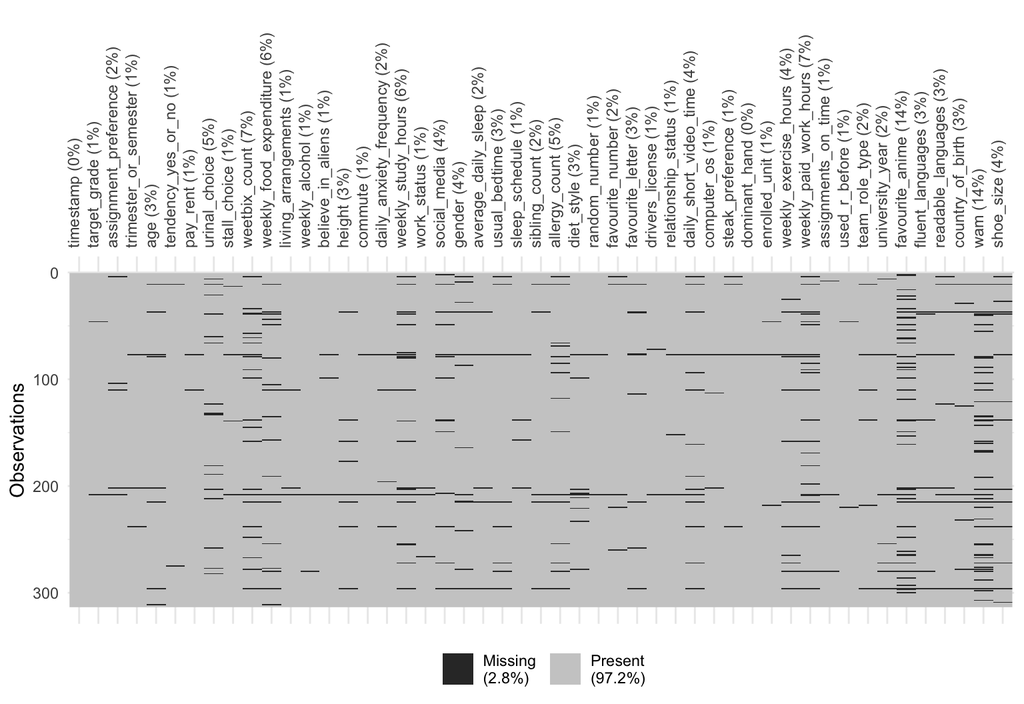

Figure 1: Visualising the missingness in the raw data. Dark cells indicate missing values

```r
visdat::vis_miss(x) +
  theme(axis.text.x = element_text(angle = 90, hjust = 0))
```

To achieve reproducibility and report flow, we will make a copy of the raw data set and wrangle accordingly for each of the analysis question in the next section.

### 2.1 Work status and country of birth

The first question will test for independence between work status and country of birth, so I plan to lump the sample into groups such as ‘Australian verses Internationals’ and ‘Employed verses Unemployed’.

We check that the joint proportion of missing values in either the work status or the country of birth is 0.035, which is not very noticeable so we can remove these columns without worrying its effect on the analysis outcome. Next we also check and remove the presence of illogical inputs in country of birth such as numbers or words that do not represent a country.

```r
x_1 <- x

#check for proportion of missing values in either columns
round(mean(is.na(x_1$work_status) | is.na(x_1$country_of_birth)), 3)

#check for illogical inputs
sort(unique(x_1$country_of_birth))
```

```r
library(dplyr)
library(forcats)

#remove missing values in either columns
x_1 <- x_1 %>%
  filter(!is.na(work_status) & !is.na(country_of_birth))

#remove illogical inputs
x_1 <- x_1 %>%
  filter(!country_of_birth %in% c("/", "2003.0", "Secondary"))

#use unique(x_1$work_status) to check the old categories
#lump the categories for work status
x_1 <- x_1 %>%
  mutate(
    work_status = fct_collapse(work_status,
                               Employed = c("Casual", "Contractor", "Self employed",
                                            "Part time", "Full time"),
                               Unemployed = "I don't currently work"
                               )
  )

#use unique(x_1$country_of_birth) to check all values
#lump categories for country of birth
x_1 <- x_1 %>%
  mutate(
    country_of_birth = fct_collapse(country_of_birth,
                                    Australians = c("Australia", "Australia!", "au",
                                                    "Aus", "australia", "AUS", "A", "aus"),
                                    Internationals = c("Bangladesh","china","China", "CHINA", "Chins", "CHN", "Denmark", "England", "France", "Germany", "Hong Kong", "Hong Kong SAR", "india", "India", "Indo", "indonesia", "Indonesia", "israel", "Japan", "malaysia","Malaysia", "Myanmar", "New Zealand", "North Korea","Pakistan","Philippines","Republic of Korea","Singapore","South Africa","South Korea","Taiwan", "Thailand", "Tianjin","UAE", "United States of America", "America", "USA", "Viet Nam","vietnam", "Vietnam")
)
)

#check all inputs have been lumped
unique(x_1$country_of_birth)
```

After cleaning, we will lump the categories in work status into Unemployed and Employed and categories in country of birth into Australians and Internationals.

We can visualize the cleaned data to be used for the first test.

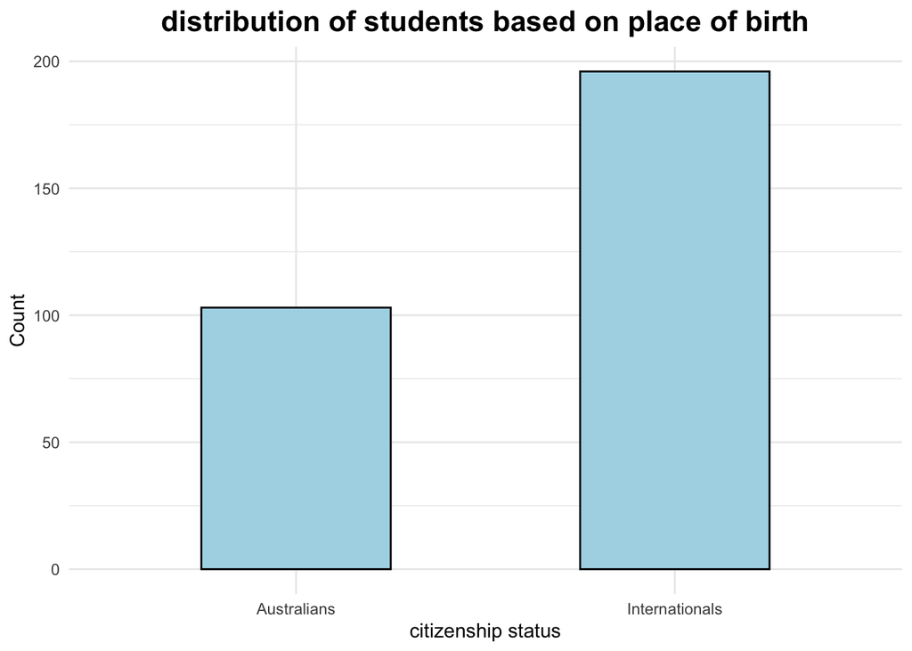

```r
x_1plot1 <- ggplot(x_1, aes(x = country_of_birth)) +
  geom_bar(fill = "lightblue", color = "black", width = 0.5) +
  labs(title = "distribution of students based on place of birth",
       x = "citizenship status",
       y = "Count") +
  theme_minimal() +
  theme(plot.title = element_text(hjust = 0.5, size = 16, face = "bold"))

x_1plot2 <- ggplot(x_1, aes(x = work_status)) +
  geom_bar(fill = "maroon", color = "black", width = 0.5) +
  labs(title = "distribution of students based on employment status",
       x = "citizenship status",
       y = "Count") +
  theme_minimal() +
  theme(plot.title = element_text(hjust = 0.5, size = 16, face = "bold"))

x_1plot1
```

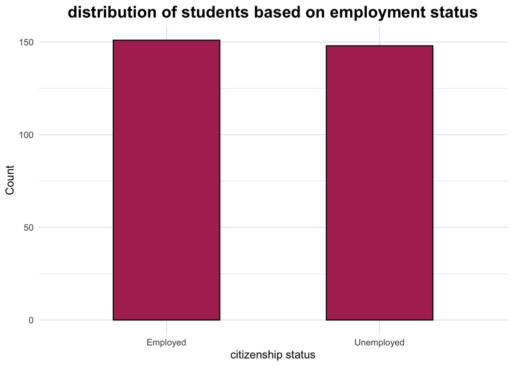

```r
x_1plot2
```

### 2.2 Two samples by country of birth and their average WAM

The second question will use a two sample t test to test difference in mean WAM between domestic and international students, so I plan to split WAM into 2 sub-samples categorized by Australians and Internationals.

We check that the joint proportion of missing values in either WAM or the country of birth is 0.147, which is a considerable proportion this time. However, we see from the previous subsection that after removing missing values and illogical inputs, there are 103 Australian students and 196 international students in the class. Hence, we can continue to remove rows with missing values and implausible inputs (like 100 or 0) under WAM, while minimizing the risk of reducing the power of the tests that we are going to perform since our sample size is still large.

```r
x_2 <- x

#check proportion of missing values
mean(is.na(x_2$wam) | is.na(x_2$country_of_birth))

#check for illogical inputs for WAM
sort(unique(x_2$wam))

#remove missing values in either columns
x_2 <- x_2 %>%
  filter(!is.na(wam) & !is.na(country_of_birth))

#remove illogical inputs for country of birth
x_2 <- x_2 %>%
  filter(!country_of_birth %in% c("/", "2003.0", "Secondary"))

#remove illogical inputs for wam
x_2 <- x_2 %>%
  filter(!(wam %in% c(0.000, 100.000)))
```

After cleaning, we now proceed to categorize the inputs in country of birth by Australians and International students just like we did previously. The grouping can be done easily with the `@dplyr` package so we will do it during the analysis.

```r
#use unique(x_2$country_of_birth) to check all values

#lump categories for country of birth
x_2 <- x_2 %>%
  mutate(
    country_of_birth = fct_collapse(country_of_birth,
                                    Australians = c("Australia", "Australia!", "au",
                                                    "Aus", "australia", "AUS", "A", "aus"),
                                    Internationals = c("Bangladesh","china","China", "CHINA", "Chins", "CHN","chian", "Denmark", "England", "France", "Germany", "Hong Kong", "Hong Kong SAR", "india", "India", "Indo", "indonesia", "Indonesia", "israel", "Japan", "malaysia","Malaysia", "Myanmar", "New Zealand", "North Korea","Pakistan","Philippines","Republic of Korea","Singapore","South Africa","South Korea","Taiwan", "Thailand", "Tianjin","UAE", "United States of America", "America", "USA", "Viet Nam","vietnam", "Vietnam")
)
)

#check all inputs have been lumped
unique(x_2$country_of_birth)
```

### 2.3 Country of birth and team role type

The third question will run a Monte Carlo simulation to test for independence between team role type and country of birth. Since Monte Carlo does not have underlying distribution assumptions, we can do a general contingency table with `length(unique(na.omit(x$team_role_type)))` columns characterized by the scale ratings and rows grouped by ‘Australian’ and ‘Internationals’.

As before, we check that the joint proportion of missing values in either team role type and country of birth is 0.042. This is not a striking proportion so we can proceed to remove these rows with missing values. we do not need to check for invalid values for team role type since it is an option based question.

```r
x_3 <- x

#check proportion of missing values in either columns
mean(is.na(x_3$team_role_type) | is.na(x_3$country_of_birth))

#remove missing values
x_3 <- x_3 %>%
  filter(!is.na(team_role_type) & !is.na(country_of_birth))

#remove illogical inputs for country of birth
x_3 <- x_3 %>%
  filter(!country_of_birth %in% c("/", "2003.0", "Secondary"))

#use unique(x_3$country_of_birth) to check all values

#lump categories for country of birth
x_3 <- x_3 %>%
  mutate(
    country_of_birth = fct_collapse(country_of_birth,
                                    Australians = c("Australia", "Australia!", "au",
                                                    "Aus", "australia", "AUS", "A", "aus"),
                                    Internationals = c("Bangladesh","china","China", "CHINA", "Chins", "CHN","chian", "Denmark", "England", "France", "Germany", "Hong Kong", "Hong Kong SAR", "india", "India", "Indo", "indonesia", "Indonesia", "israel", "Japan", "malaysia","Malaysia", "Myanmar", "New Zealand", "North Korea","Pakistan","Philippines","Republic of Korea","Singapore","South Africa","South Korea","Taiwan", "Thailand", "Tianjin","UAE", "United States of America", "America", "USA", "Viet Nam","vietnam", "Vietnam")
)
)

#check that all inputs have been lumped
unique(x_3$country_of_birth)
```

## 3 Data Analysis

### 3.1 Is there sufficient evidence to suggest a correlation between citizenship status and ease of finding a job while studying for DATA2X02 students?

[Note that we are assuming the usual case where one’s citizenship is equivalent to the place of their birth]

Let’s look at the contingency table for this question.

```r
x1_mat <- xtabs( ~ work_status + country_of_birth, data = x_1)
x1_mat
```

```
            country_of_birth
work_status  Australians Internationals
  Employed            88             63
  Unemployed          15            133
```

Check the expected cell counts.

```r
chisq.test(x1_mat)$expected |> round(1)
```

```
            country_of_birth
work_status  Australians Internationals
  Employed            52             99
  Unemployed          51             97
```

```r
chisq.test(x1_mat, correct = FALSE)
```

```
    Pearson's Chi-squared test

data:  x1_mat
X-squared = 76.715, df = 1, p-value < 2.2e-16
```

1. **Hypotheses**: $H_0:$ Ease of finding work while studying is independent of place of birth $H_1:$ Ease of finding work while studying and place of birth is not independent
2. **Assumptions**: We can argue that the observations are independent to a reasonable extent since students answer the survey on their own accord. All expected cell counts $\geq$ 5 as we calculated above. Hence, it is valid to perform a test of independence.
3. **Test statistic**: $T = \sum_{i=1}^{2} \sum_{j=1}^{2} \frac{(\frac{y_{ij}-y_{i.}y_{.j} }{n})^2}{\frac{y_{i.}y_{.j}}{n}}$
4. **Observed test statistic**: t_0 = 76.7154867
5. **p-value**: p_val = 1.9744892^{-18}

6: **Decision**: Since the p-value is much smaller than $\alpha$ = 0.05, the data provides sufficient evidence to reject the null hypothesis. There is strong evidence to sugges that ease of finding job is correlated with citizenship status in DATA2X02 student population.

### 3.2 Is the average WAM of DATA2X02 international students significantly lower than their domestic counterparts at 5% level of significance?

```r
#group the WAM by the new categories in country of birth
x2_Aus <- x_2 %>% filter(country_of_birth == "Australians") %>% pull(wam)
x2_Int <- x_2 %>% filter(country_of_birth == "Internationals") %>% pull(wam)
```

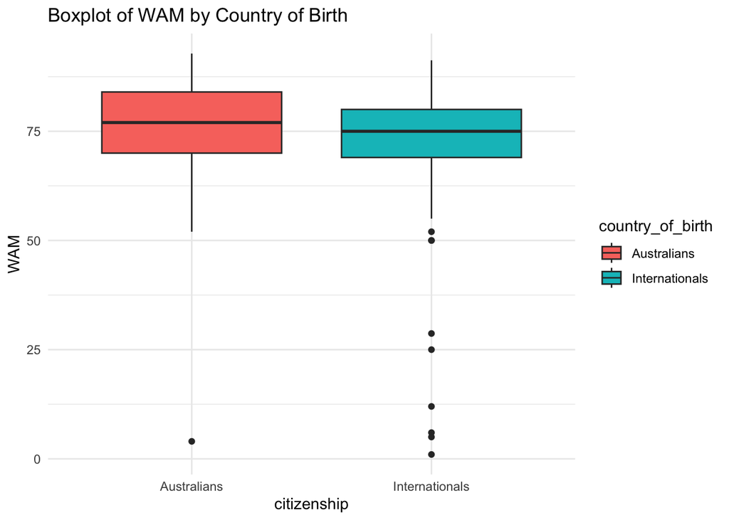

```r
#check equal variance assumptions
ggplot(x_2, aes(x = country_of_birth, y = wam, fill = country_of_birth)) +
  geom_boxplot() +
  labs(title = "Boxplot of WAM by Country of Birth",
       x = "citizenship",
       y = "WAM") +
  theme_minimal()
```

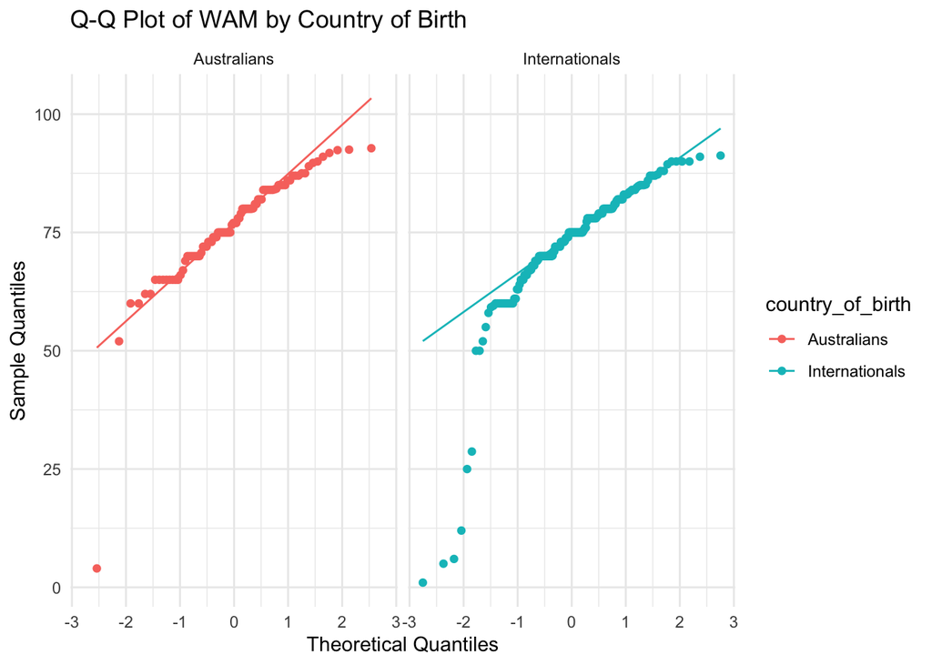

```r
#check for normality assumptions
ggplot(x_2, aes(sample = wam)) +
  stat_qq(aes(color = country_of_birth)) +
  stat_qq_line(aes(color = country_of_birth)) +
  facet_wrap(~ country_of_birth) +
  labs(title = "Q-Q Plot of WAM by Country of Birth",
       x = "Theoretical Quantiles",
       y = "Sample Quantiles") +
  theme_minimal()
```

```r
t.test(x2_Aus, x2_Int, var.equal = TRUE, alternative = 'greater')
```

```
    Two Sample t-test

data:  x2_Aus and x2_Int
t = 2.3302, df = 258, p-value = 0.01028
alternative hypothesis: true difference in means is greater than 0
95 percent confidence interval:
 1.194777      Inf
sample estimates:
mean of x mean of y
 76.16611  72.06844
```

6: **Decision**: Since the p-value is smaller than $\alpha$ = 0.05 for a one sided t test, the data provides sufficient evidence to reject the null hypothesis. There is strong evidence to suggest that average WAM of DATA2X02 international students is significantly lower than their Australian peers.

### 3.3 Is there evidence to suggest independence between citizenship status and how students perceive themselves in a team in DATA2X02 at 5% level of significance?

Let’s look at the contingency tabe for this question.

```r
x3_mat <- xtabs( ~ country_of_birth + team_role_type, data = x_3)
x3_mat
```

```
                team_role_type
country_of_birth  1  2  3  4  5  6  7  8  9 10
  Australians     1  1  0  6  7 13 20 23 19 13
  Internationals  2  5  8 11 19 27 35 50 22 15
```

```r
set.seed(2002)
#Perform simulation test
chisq.test(x3_mat, simulate.p.value = TRUE, B = 10000)
```

```
    Pearson's Chi-squared test with simulated p-value (based on 10000
    replicates)

data:  x3_mat
X-squared = 10.447, df = NA, p-value = 0.3227
```

5: **Decision**: Since the p value is much larger than $\alpha$ = 0.05, we fail to reject the null hypothesis. There is no evidence to suggest that citizenship status has any correlation to how students perceive their role in a team.

## 4 Conclusion

Consolidating the result findings from the data analysis, there seems to be some truth to the primary concerns of international students studying at Australian universities if we choose to believe that DATA2X02 student population can be representative of the broader context.

Nevertheless, within the sample we can be 95% confident to say that citizenship status may indeed affect one’s chance to get a job while studying and also perhaps on average Australian students do perform significantly better than their peers in school. However, it is interesting to see that how actively a student thinks they participate in a team is not related to where the student is from. This contradicts with some students’ impression that international students tend to be less out spoken in group projects due to reasons like language barrier and others.

##References

OpenAI. (2023). ChatGPT (Mar 14 version) [Large language model].

## 5 Tutor Feedback

Good work! You’ve done quite well with the assignment and it’s clear you’ve put a lot of effort in. In addition to the comments in the rubric, my general comments are:

Please check your submission after submitting into Canvas to make sure the citations show up right. You could’ve included more references. Missing citations are the R packages used and maybe some news article to substantiate the story context.

Some good discussion and excellent overarching theme.

Data cleaning section could be more concise - for example distribution of students by place of birth and employment status could be made into one proportion plot.

Some raw tibble outputs, some issues with formatting and Latex particularly in 3.2, a couple of mislabels.

For test 2, the QQplot shows that internationals really do tail off at the lower end - not really that normal, though the boxplot was fine for assuming normality. - you should’ve stated this. Limitations not stated. Could have stated that normality is debatable given the outlier tail in the QQplot so to justify the limitation of the two sample t test result.

For Monte Carlo test, Limitations not stated. One of the cells contains 0, could have collapsed the rating columns into broader rating range.